# Sesión 1: Model Lineal General, caso IMDb

MLGz

18 de septiembre de 2018

# IMDb data

El conjunto de datos contiene información de 322 películas de cine de USA de la última década. Los datos se han recogido de la web www.imdb.com e incluyen la siguiente información:

- movie_title: Título de la película
- gross: Recaudación total (millones de $)
- budget: Presupuesto (millones de $)
- duration: Duración (minutos)
- title_year: Año de estreno
- actor1_fl: Popularidad del primer actor (número de “Likes” en Facebook)
- actor2_fl: Popularidad del segundo actor (número de “Likes” en Facebook)
- actor3_fl: Popularidad del tercer actor (número de “Likes” en Facebook)
- cast_fl: Popularidad total del casting (número de “Likes” en Facebook)
- faces_poster: Número de caras que aparecen en el póster
- Genre: Género de la película (Comedy, Drama, Action, Horror)

Se pretende explorar las relaciones entre las variables recogidas y la recaudación de la película.

```r
data=read.csv2("IMDb.csv")
summary(data)
```

```
##             movie_title      gross               budget
##  12 Years a Slave :  1   Min.   :  2694973   Min.   :   700000
##  1408             :  1   1st Qu.: 33421866   1st Qu.: 20000000
##  2012             :  1   Median : 63590421   Median : 40000000
##  21 & Over        :  1   Mean   : 96911533   Mean   : 66710559
##  27 Dresses       :  1   3rd Qu.:126948102   3rd Qu.: 90000000
##  30 Days of Night :  1   Max.   :760505847   Max.   :300000000
##  (Other)          :316
##     duration     title_year    director_fl         actor1_fl
##  Min.   : 80   Min.   :2006   Min.   :    0.00   Min.   :  129.0
##  1st Qu.:101   1st Qu.:2008   1st Qu.:   19.25   1st Qu.:  989.5
##  Median :112   Median :2011   Median :   98.00   Median :11000.0
##  Mean   :116   Mean   :2011   Mean   : 1173.80   Mean   :11069.4
##  3rd Qu.:128   3rd Qu.:2013   3rd Qu.:  301.00   3rd Qu.:16750.0
##  Max.   :195   Max.   :2016   Max.   :21000.00   Max.   :49000.0
##
##    actor2_fl       actor3_fl          cast_fl       faces_poster
##  Min.   :    4   Min.   :    0.0   Min.   :  214   Min.   : 0.000
##  1st Qu.:  564   1st Qu.:  309.2   1st Qu.: 3196   1st Qu.: 0.000
##  Median :  893   Median :  585.5   Median :13316   Median : 1.000
##  Mean   : 3443   Mean   : 1410.8   Mean   :17405   Mean   : 1.543
##  3rd Qu.: 3000   3rd Qu.:  916.8   3rd Qu.:25255   3rd Qu.: 2.000
##  Max.   :25000   Max.   :19000.0   Max.   :92000   Max.   :31.000
##
##     Genre
##  Action: 74
##  Comedy:101
##  Drama : 99
##  Horror: 48
##
##
##
```

```r
row.names(data)=data[,1]
data=data[,-1]
head(data)
```

```
##                                               gross    budget duration
## Avatar                                    760505847 237000000      178
## Pirates of the Caribbean: At World's End  309404152 300000000      169
## John Carter                                73058679 263700000      132
## Spider-Man 3                              336530303 258000000      156
## Avengers: Age of Ultron                   458991599 250000000      141
## Batman v Superman: Dawn of Justice        330249062 250000000      183
##                                           title_year director_fl actor1_fl
## Avatar                                          2009           0      1000
## Pirates of the Caribbean: At World's End        2007         563     40000
## John Carter                                     2012         475       640
## Spider-Man 3                                    2007           0     24000
## Avengers: Age of Ultron                         2015           0     26000
## Batman v Superman: Dawn of Justice              2016           0     15000
##                                           actor2_fl actor3_fl cast_fl
## Avatar                                          936       855    4834
## Pirates of the Caribbean: At World's End       5000      1000   48350
## John Carter                                     632       530    1873
## Spider-Man 3                                  11000      4000   46055
## Avengers: Age of Ultron                       21000     19000   92000
## Batman v Superman: Dawn of Justice             4000      2000   24450
##                                           faces_poster  Genre
## Avatar                                               0 Action
## Pirates of the Caribbean: At World's End             0 Action
## John Carter                                          1 Action
## Spider-Man 3                                         0 Action
## Avengers: Age of Ultron                              4 Action
## Batman v Superman: Dawn of Justice                   0 Action
```

**COMENTARIS:** row.names(data)=data[,1] per prescindir de la codificació de cada nm i quedarnos nomes amb la etiqueta del titul de la película.

## Regresión Lineal Múltiple (sólo covariables)

**COMENTARIS:** Descartem en aquest apartat la variable gènere (per ser string) i l’any de la peli (perquè no sembla raonable que l’haguem d’introduir com a numèrica per explicar el model) i per a la RLM només hem de tenir variables quantitatives.

Així doncs, treballarem amb l’any més endavant com a categòrica i fixarem períodes.

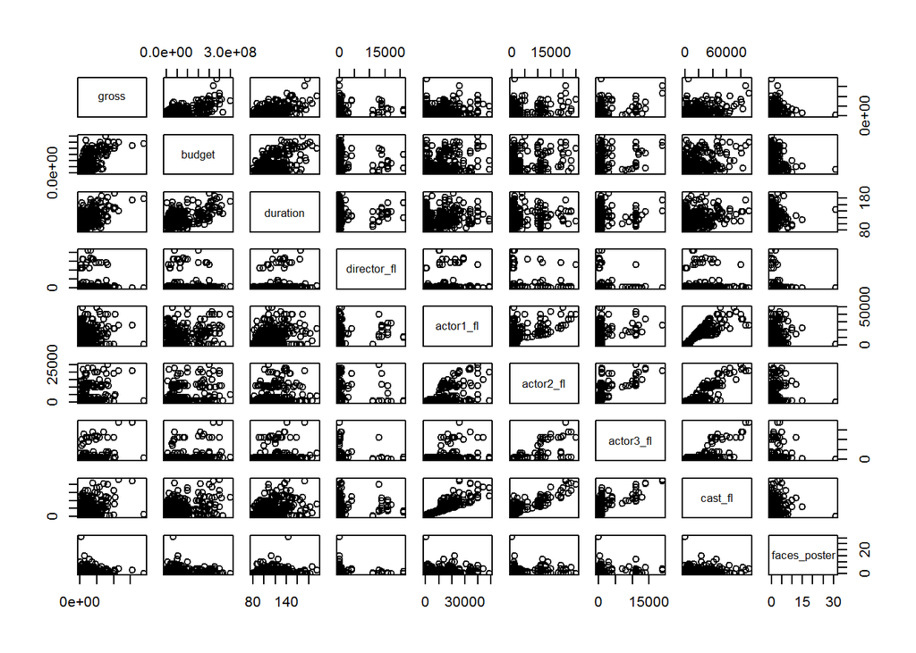

```r
pairs(data[,c(1:3,5:10)])
```

**COMENTARIS:** A sobre veiem un MATRIXPLOT, podem veure les relacions (regresións) lineals de totes les variables que hem deixat.

REVISEM QUE LES ESCALES SIGUIN RAONABLES:El primer que cal observar és que tant la recaptació com el pressupost tenen una escala que és en dolars que fan que l’escala sigui molt gran.

Quan els valors son tant grans les betas del model la variància residual sera de 10^-13, fa que l’estimació dels coeficients sigui inestable. També passa si l’escala es molt petita (molts decimals)

A continuació veiem al gràfics que l’escala esta sobre 10^+8 i 3^+8.

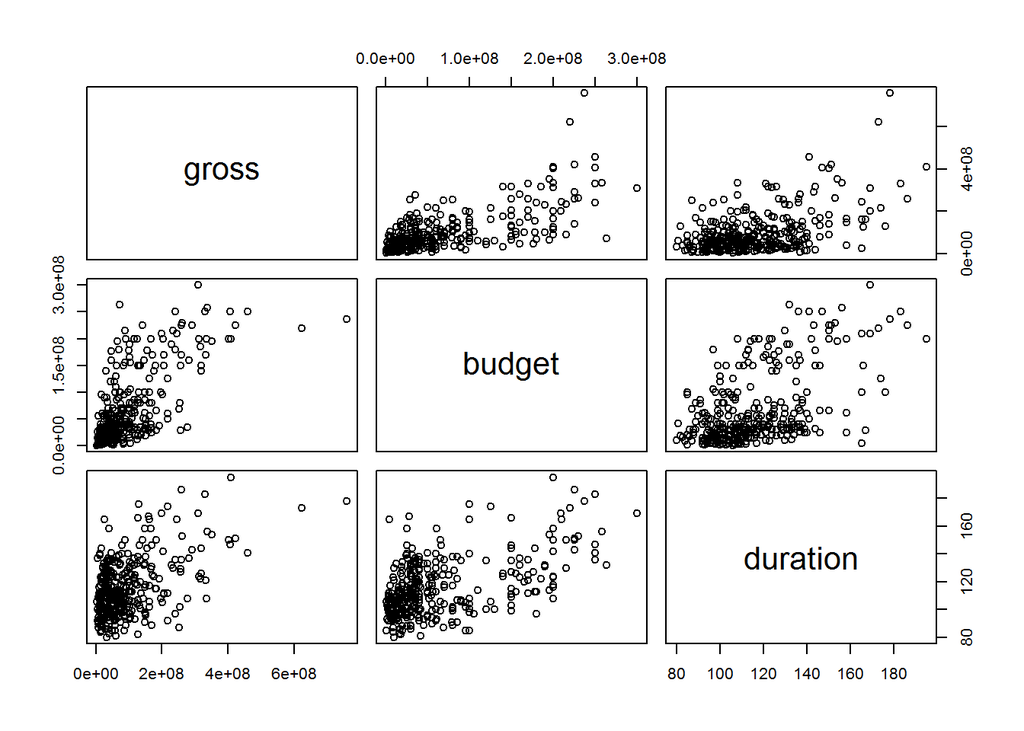

```r
pairs(~gross+budget+duration,data)
```

El gràfic anterior ens permet veure si hi ha relació i si la relació es positiva o negativa. També, ens ajuda a diagnosticar si hi haurá multicolinealitat.

Més concretament, entre gross-budget i gross-dration sembla que a més pressupost més recaptació pero conforme aumenta el gross aumenta la variabilitat. El mateix passa amb la duració. Això, com ja sabem es motiu de heteroscedasticitat. (mirem el summary de: summary(mod<-lm(gross~duration+budget,data))).

Així doncs, dividim per un milió (10^6) les dues variables de es que parlavem. Ara estan en milions de dolars i no en dolars.

```r
data$gross=data$gross/1e6
data$budget=data$budget/1e6
data$year=factor(cut(data$title_year,c(0,2008,2012,2017)),labels=c("2006-2008","2009-2012","2013-2016"))
summary(data)
```

```
##      gross             budget          duration     title_year
##  Min.   :  2.695   Min.   :  0.70   Min.   : 80   Min.   :2006
##  1st Qu.: 33.422   1st Qu.: 20.00   1st Qu.:101   1st Qu.:2008
##  Median : 63.590   Median : 40.00   Median :112   Median :2011
##  Mean   : 96.912   Mean   : 66.71   Mean   :116   Mean   :2011
##  3rd Qu.:126.948   3rd Qu.: 90.00   3rd Qu.:128   3rd Qu.:2013
##  Max.   :760.506   Max.   :300.00   Max.   :195   Max.   :2016
##   director_fl         actor1_fl         actor2_fl       actor3_fl
##  Min.   :    0.00   Min.   :  129.0   Min.   :    4   Min.   :    0.0
##  1st Qu.:   19.25   1st Qu.:  989.5   1st Qu.:  564   1st Qu.:  309.2
##  Median :   98.00   Median :11000.0   Median :  893   Median :  585.5
##  Mean   : 1173.80   Mean   :11069.4   Mean   : 3443   Mean   : 1410.8
##  3rd Qu.:  301.00   3rd Qu.:16750.0   3rd Qu.: 3000   3rd Qu.:  916.8
##  Max.   :21000.00   Max.   :49000.0   Max.   :25000   Max.   :19000.0
##     cast_fl       faces_poster       Genre            year
##  Min.   :  214   Min.   : 0.000   Action: 74   2006-2008: 92
##  1st Qu.: 3196   1st Qu.: 0.000   Comedy:101   2009-2012:127
##  Median :13316   Median : 1.000   Drama : 99   2013-2016:103
##  Mean   :17405   Mean   : 1.543   Horror: 48
##  3rd Qu.:25255   3rd Qu.: 2.000
##  Max.   :92000   Max.   :31.000
```

```r
table(data$title_year,data$year)
```

```
##
##        2006-2008 2009-2012 2013-2016
##   2006        27         0         0
##   2007        30         0         0
##   2008        35         0         0
##   2009         0        30         0
##   2010         0        30         0
##   2011         0        36         0
##   2012         0        31         0
##   2013         0         0        44
##   2014         0         0        29
##   2015         0         0        23
##   2016         0         0         7
```

```r
summary(mod<-lm(gross~duration+budget,data))
```

```
##
## Call:
## lm(formula = gross ~ duration + budget, data = data)
##
## Residuals:
##     Min      1Q  Median      3Q     Max
## -211.22  -36.89   -9.12   24.77  459.87
##
## Coefficients:
##              Estimate Std. Error t value Pr(>|t|)
## (Intercept) -62.42543   23.52546  -2.654  0.00836 **
## duration      0.86688    0.21816   3.974 8.76e-05 ***
## budget        0.88083    0.06832  12.893  < 2e-16 ***
## ---
## Signif. codes:  0 '***' 0.001 '**' 0.01 '*' 0.05 '.' 0.1 ' ' 1
##
## Residual standard error: 69.33 on 319 degrees of freedom
## Multiple R-squared:  0.5088, Adjusted R-squared:  0.5057
## F-statistic: 165.2 on 2 and 319 DF,  p-value: < 2.2e-16
```

```r
summary(modb<-glm(gross~duration+budget,data,family=gaussian))
```

```
##
## Call:
## glm(formula = gross ~ duration + budget, family = gaussian, data = data)
##
## Deviance Residuals:
##     Min       1Q   Median       3Q      Max
## -211.22   -36.89    -9.12    24.77   459.87
##
## Coefficients:
##              Estimate Std. Error t value Pr(>|t|)
## (Intercept) -62.42543   23.52546  -2.654  0.00836 **
## duration      0.86688    0.21816   3.974 8.76e-05 ***
## budget        0.88083    0.06832  12.893  < 2e-16 ***
## ---
## Signif. codes:  0 '***' 0.001 '**' 0.01 '*' 0.05 '.' 0.1 ' ' 1
##
## (Dispersion parameter for gaussian family taken to be 4806.642)
##
##     Null deviance: 3121339  on 321  degrees of freedom
## Residual deviance: 1533319  on 319  degrees of freedom
## AIC: 3648.6
##
## Number of Fisher Scoring iterations: 2
```

*SORTIDA DEL PRIMER OUTPUT:* HO: beta(i)=0 H1; beta(i)!=0

Model teòric: Y=Xbeta+errors Model ajustat: Y=Xbeta_barret+residus

La durada té influencia en la recaptació? Si, rebutjem la hip nul.la degut a ca el pvalor associada al t valor és significatiu. Malgrat aixó, al no tractar-se d’un disseny experimental sinó de dades obsrvacionals, no podem parlar de causalitat. Només de que hi ha relació.

En la darrera línia observem una comparació entre el model bo i el model ajustat, com que el p valor és menor a 0.05, diem que el model és significatiu.

*SORTIDA DEL SEGON OUTPUT:* glm : per a models lineals generalitats. a més de les variables, li hem d’indicar la familia. Dient que la familia es gaussiaa, estem indicant que la var y segueix una nomal.

Ara apareix la deviança i els residus de la devianá pero no el Rquadrat ni el Rquadrat ajustat.

Dispersion parameter for gaussian family taken to be 4806.642 és la variància residual. OBSERVAR que en l’apartat anterior tenim el “Residual standard error: 69.33”, que és el mateix!!

*RESIDUAL DEVIANÇA*:

RSS: sum(Y_i - mu_barret_i)^2

DF (graus de ll): N-P = 322-3=319 sigma_barret^2 = RSS/(N-P)

*NULL DIAVIANÇA*:

sum(Y_i - Y_guió_i)^2 DF: N-1 var_barret (Y_i) = sigma_barret^2= [sum(Y_i - Y_guió_i)^2]/N-1

Veiem que reduint una mica els paràmetres(de 321 a 319) la deviança es molt menor. Si a un model li afegim una variable la deviaça hauria de baixar, si no baixa, cal descartar el paràmetre que s’ha agefit.

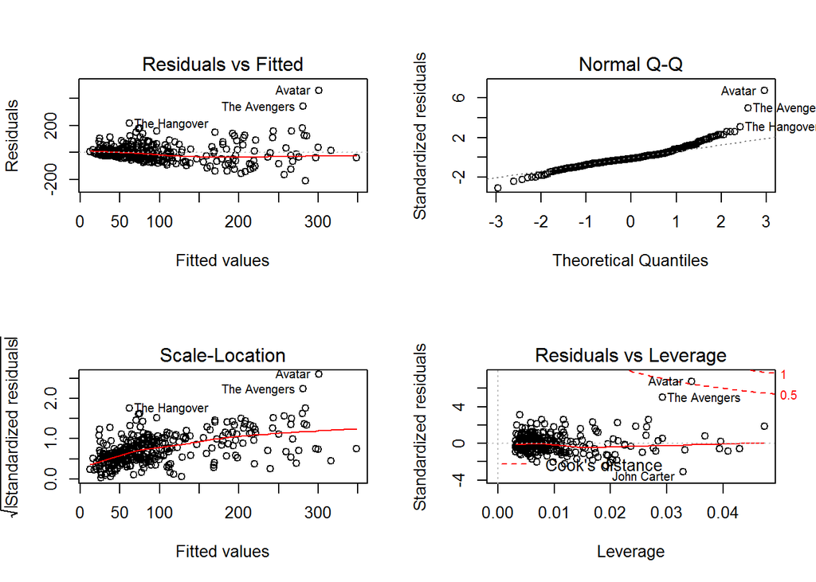

```r
par(mfrow=c(2,2))
plot(mod)
```

```r
par(mfrow=c(1,1))
```

Aquest son els plots de validació: 1. Residus enfront de prediccions Per veure la linealitat. 2. Plot de normalitat. Per veure la normalitat 3. Scale location: arrel quadrada del primer amb un ajust suau.: Per veure si hi ha variancia constant. 4. Residual vs leverage. PEr veure les observacions més influents. (o si hi ha una variable que sigui influient)

En el primer plot veiem molt clarametn que hi ha heteroscedasticitat. I amb la tercera confirmam que conforme augmenta la predicció, augemta la variança (variabilitat).

Així, el model no queda validat, i cal aplicar logaritmes.

**TRANFORMACIÓ LOGARÍTMICA:**

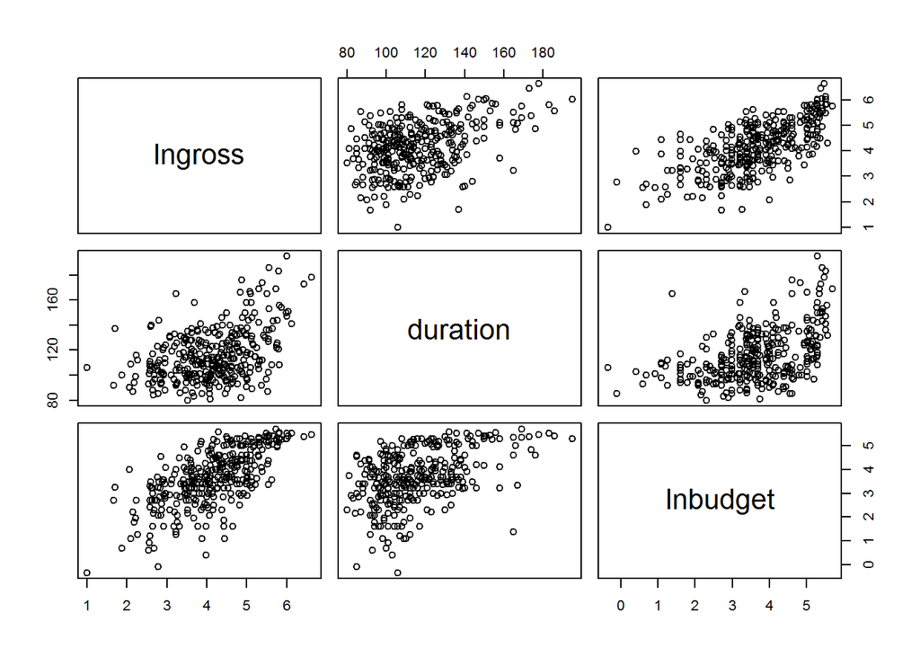

```r
data$lngross=log(data$gross)
data$lnbudget=log(data$budget)

pairs(~lngross+duration+lnbudget,data)
```

Treballarem amb el logarítmes. Ja no queda clar ’efecte trompeta que veiem abans. La variancia sembla mes constant.

Ajustem el model nou:

```r
summary(mod<-lm(lngross~duration+lnbudget,data))
```

```
##
## Call:
## lm(formula = lngross ~ duration + lnbudget, data = data)
##
## Residuals:
##      Min       1Q   Median       3Q      Max
## -2.37530 -0.48577  0.01769  0.47950  1.70384
##
## Coefficients:
##             Estimate Std. Error t value Pr(>|t|)
## (Intercept) 1.563544   0.225737   6.926 2.39e-11 ***
## duration    0.006298   0.002153   2.925  0.00369 **
## lnbudget    0.505326   0.038753  13.040  < 2e-16 ***
## ---
## Signif. codes:  0 '***' 0.001 '**' 0.01 '*' 0.05 '.' 0.1 ' ' 1
##
## Residual standard error: 0.7148 on 319 degrees of freedom
## Multiple R-squared:  0.4622, Adjusted R-squared:  0.4588
## F-statistic: 137.1 on 2 and 319 DF,  p-value: < 2.2e-16
```

```r
summary(modb<-glm(lngross~duration+lnbudget,data,family=gaussian))
```

```
##
## Call:
## glm(formula = lngross ~ duration + lnbudget, family = gaussian,
##     data = data)
##
## Deviance Residuals:
##      Min        1Q    Median        3Q       Max
## -2.37530  -0.48577   0.01769   0.47950   1.70384
##
## Coefficients:
##             Estimate Std. Error t value Pr(>|t|)
## (Intercept) 1.563544   0.225737   6.926 2.39e-11 ***
## duration    0.006298   0.002153   2.925  0.00369 **
## lnbudget    0.505326   0.038753  13.040  < 2e-16 ***
## ---
## Signif. codes:  0 '***' 0.001 '**' 0.01 '*' 0.05 '.' 0.1 ' ' 1
##
## (Dispersion parameter for gaussian family taken to be 0.5108971)
##
##     Null deviance: 303.05  on 321  degrees of freedom
## Residual deviance: 162.98  on 319  degrees of freedom
## AIC: 702.53
##
## Number of Fisher Scoring iterations: 2
```

En el primer model veiem els tres parametres significatius.

La variància ja no es comparable amb l’anterior, ara hemcanviat l’escala.

El r^2 abans era 0.50 i ara 0.46, això vol dir que aquest model es pitjor? Que explica menys la variabilitat de la resposta?

No, NO son comparables perquè hem canviat l’escala de la resposta.

Podem dir que la variabilitat está exlicada en u 46%.

El AIC y la deviança del segon sumarytambpoc son comparables si canviem l’escala de la var resposta.

**ANOVA**

```r
anova(mod)
```

```
## Analysis of Variance Table
##
## Response: lngross
##            Df  Sum Sq Mean Sq F value    Pr(>F)
## duration    1  53.203  53.203  104.14 < 2.2e-16 ***
## lnbudget    1  86.871  86.871  170.04 < 2.2e-16 ***
## Residuals 319 162.976   0.511
## ---
## Signif. codes:  0 '***' 0.001 '**' 0.01 '*' 0.05 '.' 0.1 ' ' 1
```

```r
Anova(mod,type=3)
```

```
## Anova Table (Type III tests)
##
## Response: lngross
##              Sum Sq  Df  F value    Pr(>F)
## (Intercept)  24.510   1  47.9751 2.388e-11 ***
## duration      4.371   1   8.5546  0.003693 **
## lnbudget     86.871   1 170.0365 < 2.2e-16 ***
## Residuals   162.976 319
## ---
## Signif. codes:  0 '***' 0.001 '**' 0.01 '*' 0.05 '.' 0.1 ' ' 1
```

Hi ha una variabilitat total que la dividim en sumes de quadrats associades a les diferents variables que tenim i obtenim un valor F i uns pvalors associats.

Anova (amb majúscula del paquet car) és el mètode anova pero amb el tipus:3.

Veiem que no coincideixen, hi ha diferències.

Mètode anova d’un model (làsic) tenim la taula de la anova sequencial, ja que els pvalors ens estan comparant el model en que no hi ha res amb el model que te la durada, el segonpvalor hem compara el model amb la durada amb el model am la durada i el lnbudget, i així successivament. Només que escrivim les var en un ordre diferent, els pvalors seran diferents perque els models q comparara ja no seran iguals

El Mètode Anova, es el que es diu marginal o —. Compara el model complet (amb totes les vars) amb el model sense la variable duration (pel cas del pvalor associat a la variable duration). Si es significatiu, significa que la variable ha d’estar dintre del model.

Type= 2 o type=3, té a veure quan hi ha interaccions. Amb el tipus dos inclou les interaccions encara que elimini la variable.

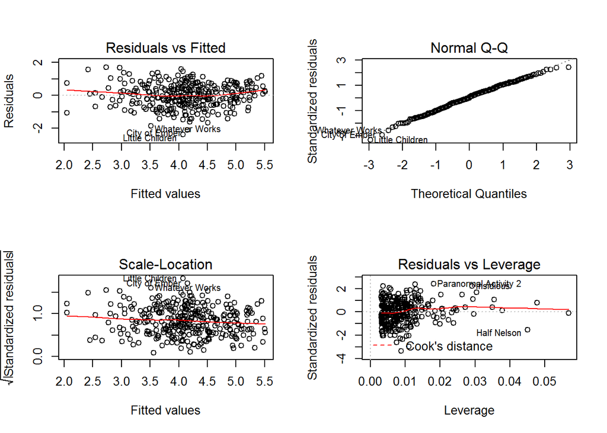

```r
par(mfrow=c(2,2))
plot(mod)
```

```r
par(mfrow=c(1,1))
```

La normalitat és indiscutible. La variança sembla constant perque veiem una variabilitat constant, no depen de les prediccions. Els residus tamb son propers a 0, encara que si hi ha algun nivels separats però no molts.

**NOUS PLOTS:**

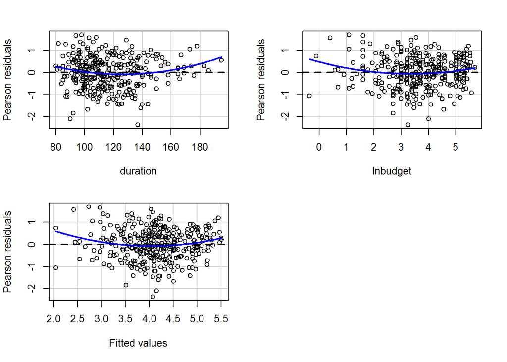

```
##            Test stat Pr(>|Test stat|)
## duration      2.6007         0.009737 **
## lnbudget      2.3654         0.018608 *
## Tukey test    2.8009         0.005095 **
## ---
## Signif. codes:  0 '***' 0.001 '**' 0.01 '*' 0.05 '.' 0.1 ' ' 1
```

```r
residualPlots(mod)
```

El 3er es el mateix que abans (el primer d’abans): residus enfront a les prediccions. Però els dos primers son l’enfrontament dels residus ambcada una de les variables.

Ve acompanyart d’un test, que em permet veure si hi ha curvatura. Per saber si cal introduir les variables al quadrat.

**TEST DE NORMALITA:**

```r
shapiro.test(resid(mod))
```

```
##
##  Shapiro-Wilk normality test
##
## data:  resid(mod)
## W = 0.99474, p-value = 0.3379
```

```r
shapiro.test(rstudent(mod))
```

```
##
##  Shapiro-Wilk normality test
##
## data:  rstudent(mod)
## W = 0.99481, p-value = 0.3495
```

```r
par(mfrow=c(1,2))
qqPlot(resid(mod))
```

```
## Little Children    City of Ember
##              270              168
```

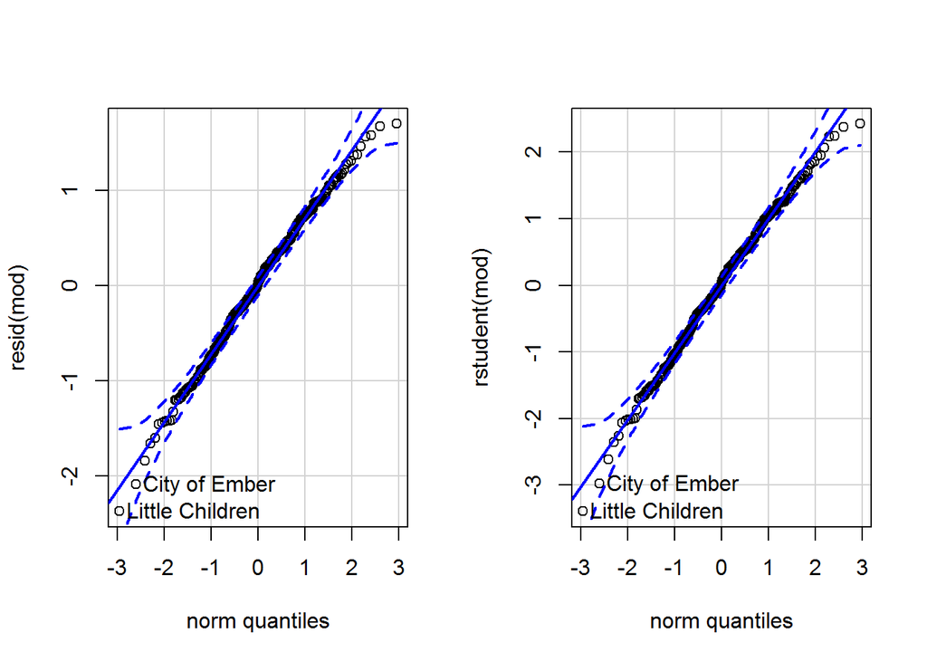

```
## Little Children    City of Ember
##              270              168
```

```r
qqPlot(rstudent(mod))
```

```r
par(mfrow=c(1,1))
```

El test ens dona un estadistic i un pvalor normal tant per als residus normals (0.33) com per als residus estudentitzats(0.34). Això ens permet assegurar la normalitat dels residus.

Residus estandaritzats: amb valors atípics és molt gran (s’infla)

Residus estudentitzats: a cada observacio li resto la prediccio i divideixo per la desv estandard eliminant la obs atípica.

Amb el qq plot podem introduir les regions de confianza i aixi la normalitat queda molt mes validad.

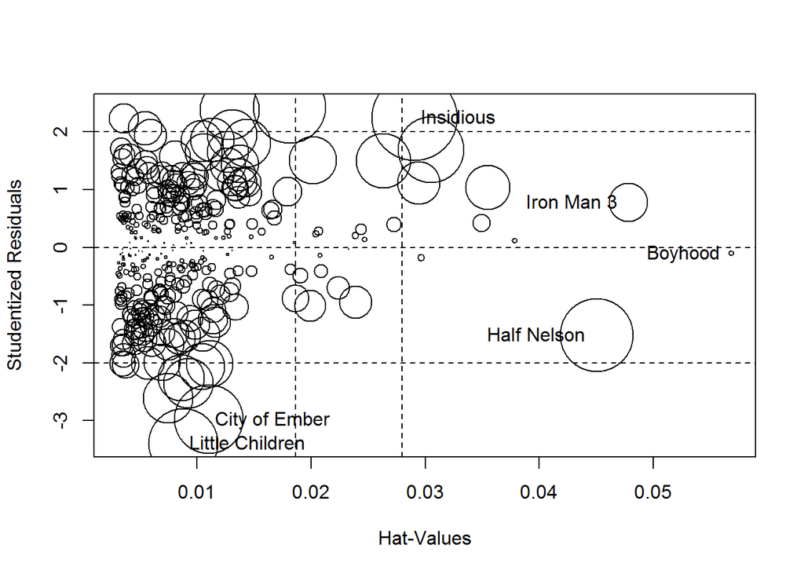

```
##                     StudRes         Hat        CookD
## Iron Man 3        0.7805368 0.047808701 0.0102089368
## City of Ember    -2.9793434 0.011061184 0.0322967671
## Little Children  -3.3924045 0.008791767 0.0329404439
## Boyhood          -0.1007410 0.056813582 0.0002044067
## Insidious         2.2457271 0.029091996 0.0497414095
## Half Nelson      -1.5198910 0.045016624 0.0361493771
```

```r
influencePlot(mod)
```

Aques plot es igual que el quart plot de la funcio plot(), combina la desv estandard amb el leverage. Quan les boles son grans, significa que tenen la dist de cook mes gran (son influents). Si les suprimim tendrem una estimació mes robusta.

Boyhood te una distancia de cook molt petita (esta molt ben predita, estimada) tot i que el leverage es molt alt. això és, que està mot allunyada, però no produeix palancament i per tant no em canvia la pendent de la recta de regressió (no és influent)

El leverage no depen de la resposta, es una funcio de la matriu de disseny.

Això ho podem veure també amb la taula de sota el gràfic, on apareixen les dades influents (distancia de cook gran o un leverage(hat) gran).

Residus: residu positiu, s’ha recaptat mes de lo que indicaba la prediccio (residu=observat-predit)

```r
outlierTest(mod)
```

```
## No Studentized residuals with Bonferonni p < 0.05
## Largest |rstudent|:
##                   rstudent unadjusted p-value Bonferonni p
## Little Children  -3.392405         0.00078037      0.25128
```

Nomes ens ho fa per a les que tenguin un residu +-3 (outliers)

Lillte children té un residu (error standard) mes gran que el valor absolut de 2

Corecció de Bonferroni(0.25): tot i que sigui un -3.39, es un valor raonable. Pot ser s’ha produit per atzar, i realment no és un atípic.

**PACKAGE EFFECTS:**

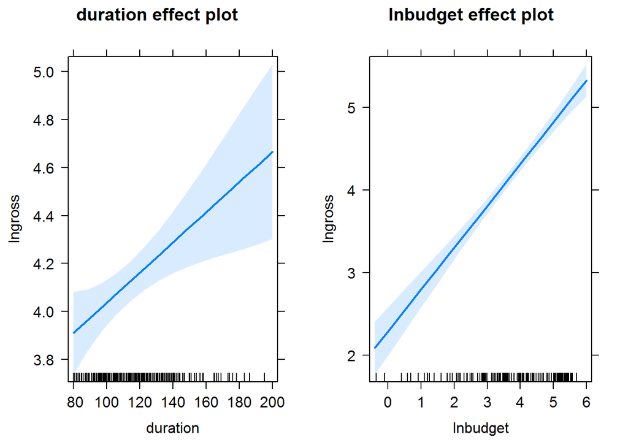

```r
plot(allEffects(mod))
```

Ens agafa del model totes les interaccions. Veiem la recta de regresió i la regió de confiança.

Ens ajuda a interpretar, i saber exactament com es mou la resposta en funció del valor de les vars explicatives

Les linies d’abaix, en el eix x, son les dades de la bbdd. És el scope, l’abast, i podem veure on s troben la majoria de les observacions. Cada línia és una observació.

**PREDICCIONS PER A UNA PELÍCULA:**

```r
pr<-predict(mod,newdata=data.frame(lnbudget=log(20),duration=90,year="2013-2016",director_fl=0,actor1_fl=0,actor2_fl=0,cast_fl=0,faces_poster=1,Genre="Horror"),interval="confidence")
exp(pr)
```

```
##       fit      lwr      upr
## 1 38.2503 33.75368 43.34595
```

```r
pr2<-predict(mod,newdata=data.frame(lnbudget=log(20),duration=90,year="2013-2016",director_fl=0,actor1_fl=0,actor2_fl=0,cast_fl=0,faces_poster=1,Genre="Horror"),interval="prediction")
exp(pr2)
```

```
##       fit      lwr      upr
## 1 38.2503 9.321664 156.9554
```

Predict em dona predicció amb un interval de confiança, el resultat es amb milions de dolars perquè ja li hem aplicat la exponencial (exp(pr)).

Interval=confidence: en promig podem garantit 38 milions, Fem la pedicció per al valor esperat.

Interval=prediction: Volem predir una película en concret, agafem un individu, per això l’interval és molt més incert.

## Análisis de la varianza (sólo factores)

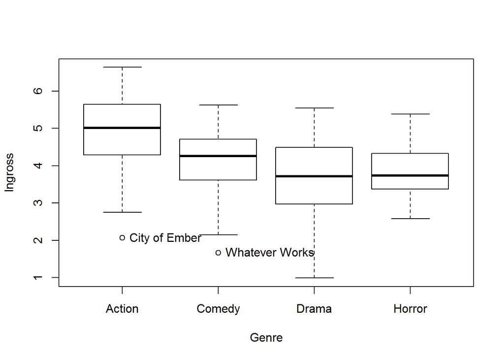

```
## [1] "City of Ember "  "Whatever Works "
```

```r
Boxplot(lngross~Genre,data)
```

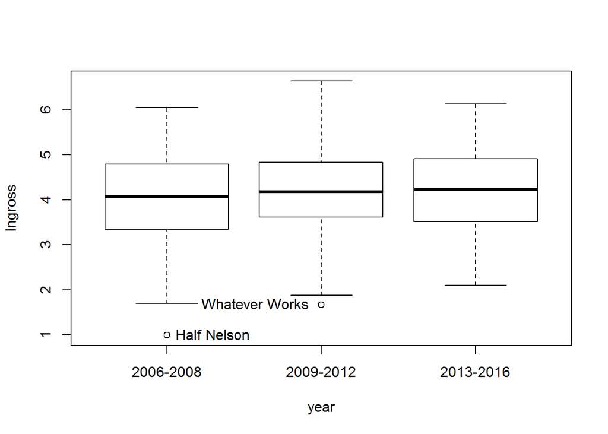

```
## [1] "Half Nelson "    "Whatever Works "
```

```r
Boxplot(lngross~year,data)
```

Ja no tenim diagrames de punts, veiem la distribució de la recaptació segons quin sigui el gènere de la película. Sembla que las de acció recaten mes q la resta, en quant a les altes no ho podem saber. Veiem dos atípics.

Quan ho feim per anys, veiem que sembla que no hi ha diferència entre la recaptacio no te a veure amb el període.

Per tant, ens centrem en el génere. La varable està codificada com un factor, stà codificada numèricament.

```r
summary(mod1<-lm(lngross~Genre,data))
```

```
##
## Call:
## lm(formula = lngross ~ Genre, data = data)
##
## Residuals:
##      Min       1Q   Median       3Q      Max
## -2.83491 -0.59705  0.02195  0.65471  1.81767
##
## Coefficients:
##             Estimate Std. Error t value Pr(>|t|)
## (Intercept)   4.8982     0.1004  48.769  < 2e-16 ***
## GenreComedy  -0.7461     0.1322  -5.643 3.70e-08 ***
## GenreDrama   -1.1709     0.1328  -8.819  < 2e-16 ***
## GenreHorror  -1.1193     0.1601  -6.990 1.62e-11 ***
## ---
## Signif. codes:  0 '***' 0.001 '**' 0.01 '*' 0.05 '.' 0.1 ' ' 1
##
## Residual standard error: 0.864 on 318 degrees of freedom
## Multiple R-squared:  0.2167, Adjusted R-squared:  0.2093
## F-statistic: 29.32 on 3 and 318 DF,  p-value: < 2.2e-16
```

Interpretació del model ajustat:

Interpretem el 4.89 com a (si el test es tipus treatment) és el valor esperat del logaritme de la recaptació si la película es d’acció. (el valor esperat de la var resposta quan el genere es el de referencia, la categoria base)

```r
Anova(mod1,type=3)
```

```
## Anova Table (Type III tests)
##
## Response: lngross
##              Sum Sq  Df  F value    Pr(>F)
## (Intercept) 1775.42   1 2378.406 < 2.2e-16 ***
## Genre         65.67   3   29.325 < 2.2e-16 ***
## Residuals    237.38 318
## ---
## Signif. codes:  0 '***' 0.001 '**' 0.01 '*' 0.05 '.' 0.1 ' ' 1
```

Per decidir si la variable es significativa.

Variables dummy.

```r
options(contrasts=c("contr.sum","contr.poly"))
contrasts(data$Genre)
```

```
##        [,1] [,2] [,3]
## Action    1    0    0
## Comedy    0    1    0
## Drama     0    0    1
## Horror   -1   -1   -1
```

```r
summary(mod1b<-lm(lngross~Genre,data))
```

```
##
## Call:
## lm(formula = lngross ~ Genre, data = data)
##
## Residuals:
##      Min       1Q   Median       3Q      Max
## -2.83491 -0.59705  0.02195  0.65471  1.81767
##
## Coefficients:
##             Estimate Std. Error t value Pr(>|t|)
## (Intercept)  4.13913    0.05036  82.199  < 2e-16 ***
## Genre1       0.75906    0.08706   8.719  < 2e-16 ***
## Genre2       0.01301    0.07894   0.165    0.869
## Genre3      -0.41181    0.07941  -5.186 3.83e-07 ***
## ---
## Signif. codes:  0 '***' 0.001 '**' 0.01 '*' 0.05 '.' 0.1 ' ' 1
##
## Residual standard error: 0.864 on 318 degrees of freedom
## Multiple R-squared:  0.2167, Adjusted R-squared:  0.2093
## F-statistic: 29.32 on 3 and 318 DF,  p-value: < 2.2e-16
```

```r
options(contrasts=c("contr.helmert","contr.poly"))
contrasts(data$Genre)
```

```
##        [,1] [,2] [,3]
## Action   -1   -1   -1
## Comedy    1   -1   -1
## Drama     0    2   -1
## Horror    0    0    3
```

```r
summary(mod1c<-lm(lngross~Genre,data))
```

```
##
## Call:
## lm(formula = lngross ~ Genre, data = data)
##
## Residuals:
##      Min       1Q   Median       3Q      Max
## -2.83491 -0.59705  0.02195  0.65471  1.81767
##
## Coefficients:
##             Estimate Std. Error t value Pr(>|t|)
## (Intercept)  4.13913    0.05036  82.199  < 2e-16 ***
## Genre1      -0.37303    0.06610  -5.643 3.70e-08 ***
## Genre2      -0.26595    0.03638  -7.311 2.17e-12 ***
## Genre3      -0.12008    0.03385  -3.548 0.000447 ***
## ---
## Signif. codes:  0 '***' 0.001 '**' 0.01 '*' 0.05 '.' 0.1 ' ' 1
##
## Residual standard error: 0.864 on 318 degrees of freedom
## Multiple R-squared:  0.2167, Adjusted R-squared:  0.2093
## F-statistic: 29.32 on 3 and 318 DF,  p-value: < 2.2e-16
```

```r
options(contrasts=c("contr.treatment","contr.poly"))
contrasts(data$Genre)
```

```
##        Comedy Drama Horror
## Action      0     0      0
## Comedy      1     0      0
## Drama       0     1      0
## Horror      0     0      1
```

```r
summary(mod1)
```

```
##
## Call:
## lm(formula = lngross ~ Genre, data = data)
##
## Residuals:
##      Min       1Q   Median       3Q      Max
## -2.83491 -0.59705  0.02195  0.65471  1.81767
##
## Coefficients:
##             Estimate Std. Error t value Pr(>|t|)
## (Intercept)   4.8982     0.1004  48.769  < 2e-16 ***
## GenreComedy  -0.7461     0.1322  -5.643 3.70e-08 ***
## GenreDrama   -1.1709     0.1328  -8.819  < 2e-16 ***
## GenreHorror  -1.1193     0.1601  -6.990 1.62e-11 ***
## ---
## Signif. codes:  0 '***' 0.001 '**' 0.01 '*' 0.05 '.' 0.1 ' ' 1
##
## Residual standard error: 0.864 on 318 degrees of freedom
## Multiple R-squared:  0.2167, Adjusted R-squared:  0.2093
## F-statistic: 29.32 on 3 and 318 DF,  p-value: < 2.2e-16
```

Contastos que treballarem: baseline (vcategoria base- treatment) o suma 0(promig- contr.sum).

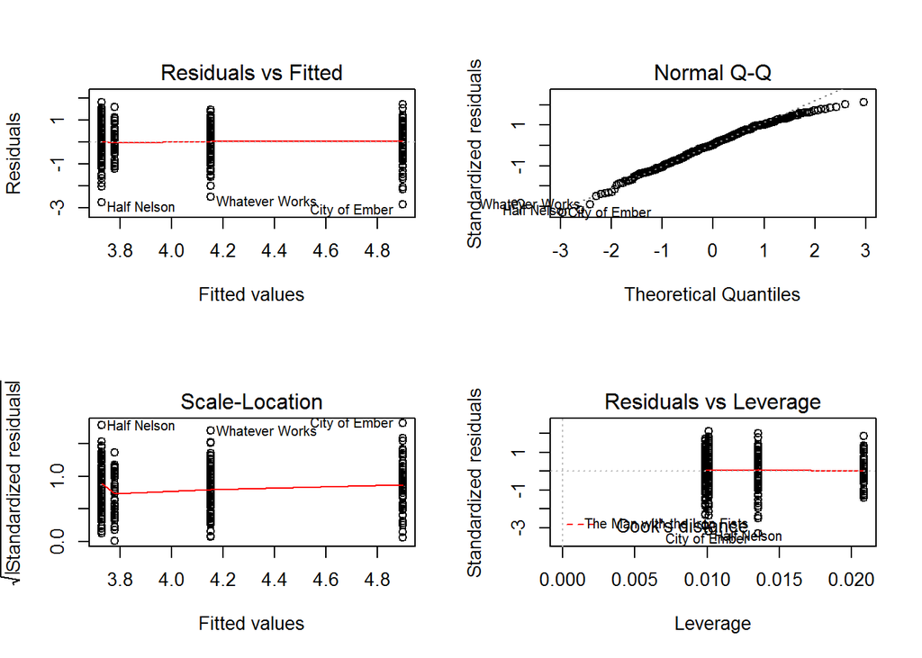

```r
par(mfrow=c(2,2))
plot(mod1)
```

```r
par(mfrow=c(1,1))
```

```r
leveneTest(mod1)
```

```
## Levene's Test for Homogeneity of Variance (center = median)
##        Df F value  Pr(>F)
## group   3  2.6812 0.04693 *
##       318
## ---
## Signif. codes:  0 '***' 0.001 '**' 0.01 '*' 0.05 '.' 0.1 ' ' 1
```

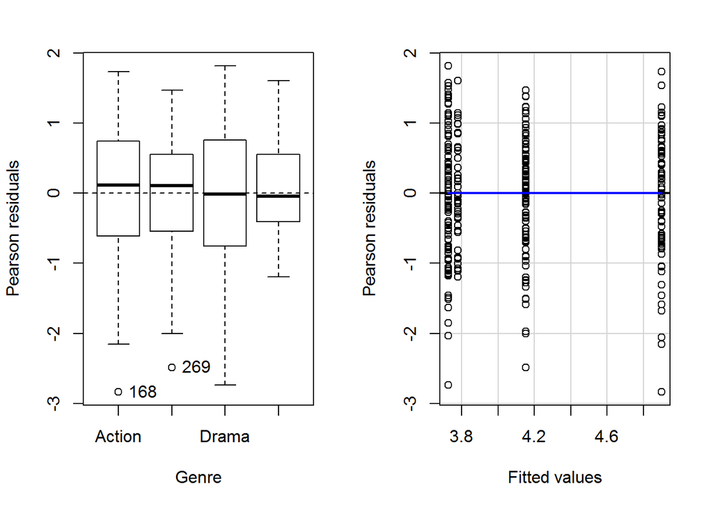

```r
residualPlots(mod1)
```

Ara, les caixes son els residus segons el génere. Per validar el model cal que les caixes estiguin alineades i que tinguin la mateixa amplada.

Validació (com abans):

```r
shapiro.test(resid(mod1))
```

```
##
##  Shapiro-Wilk normality test
##
## data:  resid(mod1)
## W = 0.98496, p-value = 0.00192
```

```r
shapiro.test(rstudent(mod1))
```

```
##
##  Shapiro-Wilk normality test
##
## data:  rstudent(mod1)
## W = 0.98477, p-value = 0.001746
```

```r
par(mfrow=c(1,2))
qqPlot(resid(mod1))
```

```
## City of Ember    Half Nelson
##            168            321
```

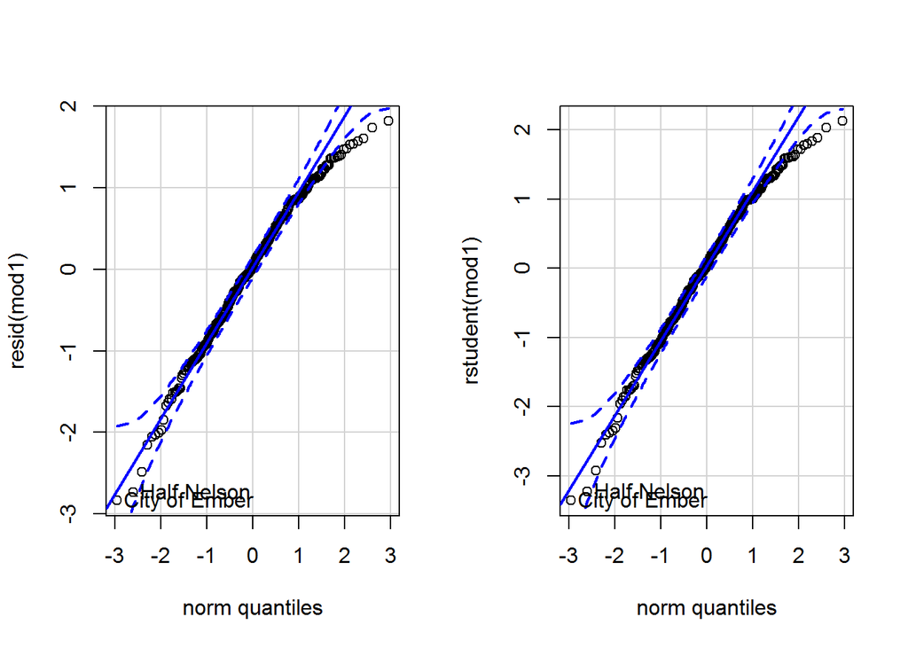

```
## City of Ember    Half Nelson
##            168            321
```

```r
qqPlot(rstudent(mod1))
```

```r
par(mfrow=c(1,1))
```

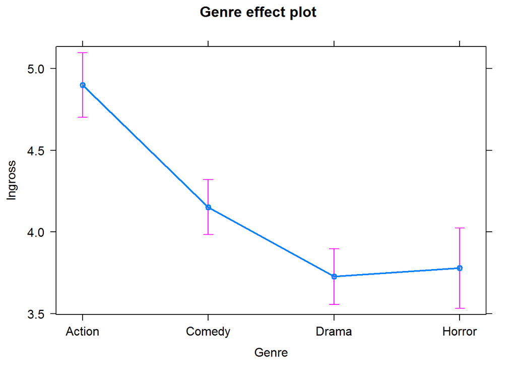

```r
plot(allEffects(mod1))
```

Valor esperat de cada gènere amb l’interval de confiança (en rosa).

```r
(emmod1<-emmeans(mod1,specs="Genre"))
```

```
##  Genre    emmean         SE  df lower.CL upper.CL
##  Action 4.898183 0.10043659 318 4.700579 5.095787
##  Comedy 4.152133 0.08597004 318 3.982991 4.321275
##  Drama  3.727313 0.08683408 318 3.556471 3.898155
##  Horror 3.778882 0.12470596 318 3.533529 4.024235
##
## Confidence level used: 0.95
```

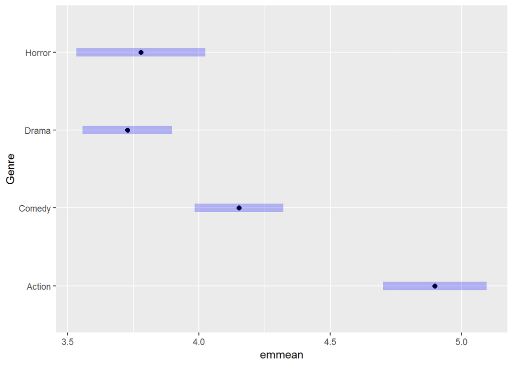

```r
plot(emmod1)
```

Plot equivalent al dels ALLEFECTS.

```r
pairs(emmod1)
```

```
##  contrast           estimate        SE  df t.ratio p.value
##  Action - Comedy  0.74605015 0.1322057 318   5.643  <.0001
##  Action - Drama   1.17086947 0.1327692 318   8.819  <.0001
##  Action - Horror  1.11930106 0.1601221 318   6.990  <.0001
##  Comedy - Drama   0.42481931 0.1221925 318   3.477  0.0032
##  Comedy - Horror  0.37325091 0.1514676 318   2.464  0.0676
##  Drama - Horror  -0.05156841 0.1519596 318  -0.339  0.9865
##
## P value adjustment: tukey method for comparing a family of 4 estimates
```

```r
cld(emmod1)
```

```
##  Genre    emmean         SE  df lower.CL upper.CL .group
##  Drama  3.727313 0.08683408 318 3.556471 3.898155  1
##  Horror 3.778882 0.12470596 318 3.533529 4.024235  12
##  Comedy 4.152133 0.08597004 318 3.982991 4.321275   2
##  Action 4.898183 0.10043659 318 4.700579 5.095787    3
##
## Confidence level used: 0.95
## P value adjustment: tukey method for comparing a family of 4 estimates
## significance level used: alpha = 0.05
```

**PREDICCIÓ:**

```r
pr<-predict(mod1,newdata=data.frame(lnbudget=log(20),duration=90,year="2013-2016",director_fl=0,actor1_fl=0,actor2_fl=0,cast_fl=0,faces_poster=1,Genre="Horror"),interval="confidence")
exp(pr)
```

```
##        fit      lwr      upr
## 1 43.76707 34.24459 55.93748
```

```r
pr2<-predict(mod1,newdata=data.frame(lnbudget=log(20),duration=90,year="2013-2016",director_fl=0,actor1_fl=0,actor2_fl=0,cast_fl=0,faces_poster=1,Genre="Horror"),interval="prediction")
exp(pr2)
```

```
##        fit      lwr      upr
## 1 43.76707 7.857047 243.8011
```

## Modelo Lineal General (factores y covariables)

Ara partim de la idea de: fes l’anàlisis nomes amb els factors(variables categòriques-year y genere- y les covariables- les numèriques), sense modificar l’escala i sense considerar interaccions.

**SELECCIÓ DE VARIABLES:**

1. Mecanismes: FORWARD: Y ~ 1 -> afegim (una variable i anem afegin allo q es significatiu). BAKWARD: Y ~ . -> treiem (ajustem el model complet (totes les vars) i anem traient tot allò no significatiu.)ç
   - Es preferible el Forward si el nom de variables és gran. Els dos ens poden donar models vàlids però diferents. STEPWISE: Y ~ . & Y ~ 1 -> treiem o afegim. És el mecanisme més preferible dels tres. En cada pas podem triar afegir o treure una variable.

En R: STEP(model de partida,scope=list(upper=model màxim), directon= FOREARD/BACKWARD/BOTH) * BOTH=STEPWISE

```r
data1=data[,c(13,14,3,5:10,11,12)]
summary(data1)
```

```
##     lngross          lnbudget          duration    director_fl
##  Min.   :0.9914   Min.   :-0.3567   Min.   : 80   Min.   :    0.00
##  1st Qu.:3.5092   1st Qu.: 2.9957   1st Qu.:101   1st Qu.:   19.25
##  Median :4.1524   Median : 3.6889   Median :112   Median :   98.00
##  Mean   :4.1373   Mean   : 3.6474   Mean   :116   Mean   : 1173.80
##  3rd Qu.:4.8438   3rd Qu.: 4.4998   3rd Qu.:128   3rd Qu.:  301.00
##  Max.   :6.6340   Max.   : 5.7038   Max.   :195   Max.   :21000.00
##    actor1_fl         actor2_fl       actor3_fl          cast_fl
##  Min.   :  129.0   Min.   :    4   Min.   :    0.0   Min.   :  214
##  1st Qu.:  989.5   1st Qu.:  564   1st Qu.:  309.2   1st Qu.: 3196
##  Median :11000.0   Median :  893   Median :  585.5   Median :13316
##  Mean   :11069.4   Mean   : 3443   Mean   : 1410.8   Mean   :17405
##  3rd Qu.:16750.0   3rd Qu.: 3000   3rd Qu.:  916.8   3rd Qu.:25255
##  Max.   :49000.0   Max.   :25000   Max.   :19000.0   Max.   :92000
##   faces_poster       Genre            year
##  Min.   : 0.000   Action: 74   2006-2008: 92
##  1st Qu.: 0.000   Comedy:101   2009-2012:127
##  Median : 1.000   Drama : 99   2013-2016:103
##  Mean   : 1.543   Horror: 48
##  3rd Qu.: 2.000
##  Max.   :31.000
```

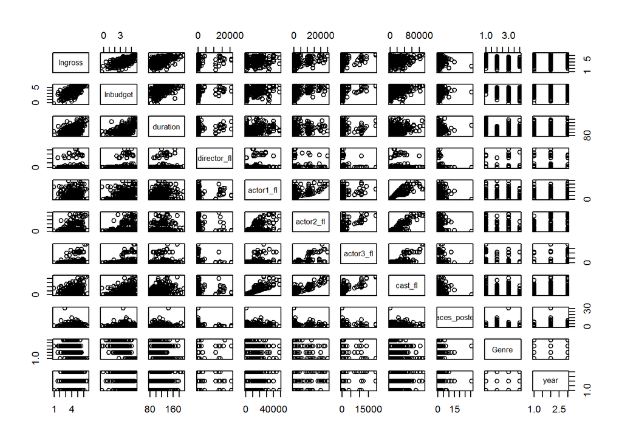

```r
pairs(data1)
```

Ens es útil per explorar quines var ens son útils per explicar la var resposta.

**SELECCIÓ DE VARIABLES:**

1. Mecanismes: FORWARD: Y ~ 1 -> afegim (una variable i anem afegin allo q es significatiu). BAKWARD: Y ~ . -> treiem (ajustem el model complet (totes les vars) i anem traient tot allò no significatiu.)ç
   - Es preferible el Forward si el nom de variables és gran. Els dos ens poden donar models vàlids però diferents. STEPWISE: Y ~ . & Y ~ 1 -> treiem o afegim. És el mecanisme més preferible dels tres. En cada pas podem triar afegir o treure una variable.

En R: STEP(model de partida,scope=list(upper=model màxim), directon= FOREARD/BACKWARD/BOTH) * BOTH=STEPWISE

FORWARD:

Ajustem primer el model null (nomes amb l’intercept) i l’indeiquem que l’abast (el upper) és el model complet.

```r
summary(m0<-lm(lngross~1,data1))
```

```
##
## Call:
## lm(formula = lngross ~ 1, data = data1)
##
## Residuals:
##      Min       1Q   Median       3Q      Max
## -3.14594 -0.62812  0.01512  0.70642  2.49665
##
## Coefficients:
##             Estimate Std. Error t value Pr(>|t|)
## (Intercept)  4.13733    0.05415   76.41   <2e-16 ***
## ---
## Signif. codes:  0 '***' 0.001 '**' 0.01 '*' 0.05 '.' 0.1 ' ' 1
##
## Residual standard error: 0.9716 on 321 degrees of freedom
```

```r
summary(m1a<-step(m0,scope=list(upper=lm(lngross~.,data1)),direction="forward"))
```

```
## Start:  AIC=-17.53
## lngross ~ 1
##
##                Df Sum of Sq    RSS      AIC
## + lnbudget      1   135.704 167.35 -206.744
## + Genre         3    65.671 237.38  -90.175
## + duration      1    53.203 249.85  -77.692
## + actor2_fl     1    33.848 269.20  -53.666
## + cast_fl       1    29.660 273.39  -48.696
## + actor3_fl     1    27.261 275.79  -45.883
## + actor1_fl     1    10.914 292.14  -27.341
## + director_fl   1     2.107 300.94  -17.777
## <none>                      303.05  -17.530
## + year          2     2.132 300.92  -15.804
## + faces_poster  1     0.003 303.05  -15.533
##
## Step:  AIC=-206.74
## lngross ~ lnbudget
##
##                Df Sum of Sq    RSS     AIC
## + actor3_fl     1    5.0337 162.31 -214.58
## + duration      1    4.3705 162.98 -213.26
## + actor2_fl     1    3.8180 163.53 -212.18
## + cast_fl       1    2.5489 164.80 -209.69
## <none>                      167.35 -206.74
## + faces_poster  1    0.8045 166.54 -206.30
## + year          2    1.7104 165.64 -206.05
## + Genre         3    2.3195 165.03 -205.24
## + actor1_fl     1    0.1322 167.21 -205.00
## + director_fl   1    0.0080 167.34 -204.76
##
## Step:  AIC=-214.58
## lngross ~ lnbudget + actor3_fl
##
##                Df Sum of Sq    RSS     AIC
## + duration      1    3.8035 158.51 -220.21
## + faces_poster  1    1.3907 160.92 -215.35
## <none>                      162.31 -214.58
## + Genre         3    2.6103 159.70 -213.80
## + actor2_fl     1    0.3250 161.99 -213.22
```

[output cut: 36 more lines]

```
## + actor2_fl    1   0.67859 147.61 -233.14
## + cast_fl      1   0.15572 148.14 -232.00
## + director_fl  1   0.04395 148.25 -231.76
## + actor1_fl    1   0.00034 148.29 -231.67
##
## Step:  AIC=-233.83
## lngross ~ lnbudget + actor3_fl + duration + Genre + faces_poster +
##     year
##
##               Df Sum of Sq    RSS     AIC
## <none>                     146.39 -233.83
## + actor2_fl    1   0.51206 145.88 -232.96
## + cast_fl      1   0.13145 146.26 -232.12
## + director_fl  1   0.03140 146.36 -231.90
## + actor1_fl    1   0.00001 146.39 -231.83
```

```
##
## Call:
## lm(formula = lngross ~ lnbudget + actor3_fl + duration + Genre +
##     faces_poster + year, data = data1)
##
## Residuals:
##      Min       1Q   Median       3Q      Max
## -2.13925 -0.42752  0.03852  0.43785  1.56770
##
## Coefficients:
##                 Estimate Std. Error t value Pr(>|t|)
## (Intercept)    1.038e+00  3.205e-01   3.239  0.00133 **
## lnbudget       4.528e-01  5.170e-02   8.760  < 2e-16 ***
## actor3_fl      4.423e-05  1.367e-05   3.235  0.00135 **
## duration       1.069e-02  2.369e-03   4.514 9.04e-06 ***
## GenreComedy    3.167e-01  1.317e-01   2.406  0.01672 *
## GenreDrama    -1.546e-01  1.418e-01  -1.090  0.27638
## GenreHorror    2.065e-01  1.646e-01   1.254  0.21078
## faces_poster  -4.019e-02  1.522e-02  -2.640  0.00870 **
## year2009-2012  1.615e-01  9.471e-02   1.705  0.08915 .
## year2013-2016  1.870e-01  1.016e-01   1.841  0.06663 .
## ---
## Signif. codes:  0 '***' 0.001 '**' 0.01 '*' 0.05 '.' 0.1 ' ' 1
##
## Residual standard error: 0.685 on 312 degrees of freedom
## Multiple R-squared:  0.5169, Adjusted R-squared:  0.503
## F-statistic:  37.1 on 9 and 312 DF,  p-value: < 2.2e-16
```

Resultats:

Quan te el mes (+), significa sobre el model 1, s’afegeix la variable. El que oposa none es el model que tenim ara. El AIC més petit es el millor model, ajusta millor les dades (el model d’adalt de tot). La AIC ens permet comparar dos models que tenen la mateixa Y.

En el segon pas, tenim com a model null el del AIC -206. y va afegint variables. Però com estem en el forward, no considera la opcio de treure ninguna variable.

Així successivament.

El darrer step serà el que tendrà el none adalt de tot, i ens quedarem amb el model anterior, es a dir, sense afegir ninguna variable mes, perqùe es el que ens aporta un AIC més baix.

Despres, obtenim el summary del model triat com a millor

BACKWARD:

Partim del model complet y apartir d’aquí, li anem traeient variables. Ja no surten (+), cada variable que ens surt significa, que passa si taiem aquesta variable?

```r
summary(m0<-lm(lngross~.,data1))
```

```
##
## Call:
## lm(formula = lngross ~ ., data = data1)
##
## Residuals:
##      Min       1Q   Median       3Q      Max
## -2.10349 -0.42581  0.03894  0.43582  1.55606
##
## Coefficients:
##                 Estimate Std. Error t value Pr(>|t|)
## (Intercept)    1.126e+00  3.282e-01   3.431 0.000683 ***
## lnbudget       4.426e-01  5.309e-02   8.338 2.56e-15 ***
## duration       1.017e-02  2.414e-03   4.212 3.33e-05 ***
## director_fl    3.708e-06  1.121e-05   0.331 0.741151
## actor1_fl     -4.318e-05  2.505e-05  -1.724 0.085755 .
## actor2_fl     -2.621e-05  2.758e-05  -0.950 0.342671
## actor3_fl     -3.191e-05  4.223e-05  -0.756 0.450433
## cast_fl        4.012e-05  2.449e-05   1.638 0.102368
## faces_poster  -3.920e-02  1.532e-02  -2.558 0.010999 *
## GenreComedy    3.029e-01  1.328e-01   2.282 0.023183 *
## GenreDrama    -1.465e-01  1.459e-01  -1.005 0.315888
## GenreHorror    1.949e-01  1.671e-01   1.167 0.244204
## year2009-2012  1.433e-01  9.539e-02   1.502 0.134117
## year2013-2016  1.646e-01  1.023e-01   1.608 0.108764
## ---
## Signif. codes:  0 '***' 0.001 '**' 0.01 '*' 0.05 '.' 0.1 ' ' 1
##
## Residual standard error: 0.6848 on 308 degrees of freedom
## Multiple R-squared:  0.5234, Adjusted R-squared:  0.5033
## F-statistic: 26.02 on 13 and 308 DF,  p-value: < 2.2e-16
```

```r
summary(m1b<-step(m0,direction="backward"))
```

```
## Start:  AIC=-230.17
## lngross ~ lnbudget + duration + director_fl + actor1_fl + actor2_fl +
##     actor3_fl + cast_fl + faces_poster + Genre + year
##
##                Df Sum of Sq    RSS     AIC
## - director_fl   1     0.051 144.48 -232.06
## - actor3_fl     1     0.268 144.69 -231.58
## - actor2_fl     1     0.424 144.85 -231.23
## - year          2     1.462 145.89 -230.93
## <none>                      144.43 -230.17
## - cast_fl       1     1.259 145.69 -229.38
## - actor1_fl     1     1.393 145.82 -229.08
## - faces_poster  1     3.069 147.50 -225.40
## - Genre         3     7.998 152.43 -218.82
## - duration      1     8.319 152.75 -214.14
## - lnbudget      1    32.597 177.02 -166.64
##
## Step:  AIC=-232.06
## lngross ~ lnbudget + duration + actor1_fl + actor2_fl + actor3_fl +
##     cast_fl + faces_poster + Genre + year
##
##                Df Sum of Sq    RSS     AIC
## - actor3_fl     1     0.264 144.74 -233.47
## - actor2_fl     1     0.405 144.88 -233.16
## - year          2     1.479 145.96 -232.78
## <none>                      144.48 -232.06
## - cast_fl       1     1.231 145.71 -231.33
## - actor1_fl     1     1.359 145.84 -231.04
## - faces_poster  1     3.189 147.67 -227.03
## - Genre         3     7.949 152.43 -220.81
## - duration      1     8.526 153.00 -215.59
## - lnbudget      1    33.682 178.16 -166.58
##
## Step:  AIC=-233.47
## lngross ~ lnbudget + duration + actor1_fl + actor2_fl + cast_fl +
##     faces_poster + Genre + year
##
##                Df Sum of Sq    RSS     AIC
## - actor2_fl     1     0.153 144.90 -235.13
## - year          2     1.565 146.31 -234.01
```

[output cut: 19 more lines]

```
## - duration      1     9.372 154.27 -216.95
## - lnbudget      1    33.510 178.41 -170.14
##
## Step:  AIC=-235.75
## lngross ~ lnbudget + duration + actor1_fl + cast_fl + faces_poster +
##     Genre
##
##                Df Sum of Sq    RSS     AIC
## <none>                      146.43 -235.75
## - faces_poster  1     2.641 149.07 -231.99
## - actor1_fl     1     3.866 150.29 -229.36
## - Genre         3     7.983 154.41 -224.65
## - cast_fl       1     6.838 153.26 -223.05
## - duration      1     9.466 155.89 -217.57
## - lnbudget      1    32.918 179.34 -172.45
```

```
##
## Call:
## lm(formula = lngross ~ lnbudget + duration + actor1_fl + cast_fl +
##     faces_poster + Genre, data = data1)
##
## Residuals:
##      Min       1Q   Median       3Q      Max
## -2.21308 -0.40790  0.05184  0.43086  1.59693
##
## Coefficients:
##                Estimate Std. Error t value Pr(>|t|)
## (Intercept)   1.251e+00  3.103e-01   4.033 6.93e-05 ***
## lnbudget      4.325e-01  5.155e-02   8.388 1.71e-15 ***
## duration      1.062e-02  2.361e-03   4.498 9.67e-06 ***
## actor1_fl    -2.255e-05  7.845e-06  -2.875 0.004323 **
## cast_fl       1.867e-05  4.884e-06   3.823 0.000159 ***
## faces_poster -3.566e-02  1.501e-02  -2.376 0.018103 *
## GenreComedy   2.713e-01  1.297e-01   2.092 0.037280 *
## GenreDrama   -1.759e-01  1.401e-01  -1.255 0.210346
## GenreHorror   1.661e-01  1.642e-01   1.012 0.312417
## ---
## Signif. codes:  0 '***' 0.001 '**' 0.01 '*' 0.05 '.' 0.1 ' ' 1
##
## Residual standard error: 0.684 on 313 degrees of freedom
## Multiple R-squared:  0.5168, Adjusted R-squared:  0.5045
## F-statistic: 41.85 on 8 and 313 DF,  p-value: < 2.2e-16
```

Resultats:

Oposat a lo anterior: anem traien la variable que esta més adalt (perquè es la que ens dona un AIC més baix si la traiem del model) fins que adalt de tot tenim la opció none.

STEPWISE:

Considera treure i reitroduir variables que ja estan fora.

```r
summary(m1c<-step(m0,direction="both"))
```

```
## Start:  AIC=-230.17
## lngross ~ lnbudget + duration + director_fl + actor1_fl + actor2_fl +
##     actor3_fl + cast_fl + faces_poster + Genre + year
##
##                Df Sum of Sq    RSS     AIC
## - director_fl   1     0.051 144.48 -232.06
## - actor3_fl     1     0.268 144.69 -231.58
## - actor2_fl     1     0.424 144.85 -231.23
## - year          2     1.462 145.89 -230.93
## <none>                      144.43 -230.17
## - cast_fl       1     1.259 145.69 -229.38
## - actor1_fl     1     1.393 145.82 -229.08
## - faces_poster  1     3.069 147.50 -225.40
## - Genre         3     7.998 152.43 -218.82
## - duration      1     8.319 152.75 -214.14
## - lnbudget      1    32.597 177.02 -166.64
##
## Step:  AIC=-232.06
## lngross ~ lnbudget + duration + actor1_fl + actor2_fl + actor3_fl +
##     cast_fl + faces_poster + Genre + year
##
##                Df Sum of Sq    RSS     AIC
## - actor3_fl     1     0.264 144.74 -233.47
## - actor2_fl     1     0.405 144.88 -233.16
## - year          2     1.479 145.96 -232.78
## <none>                      144.48 -232.06
## - cast_fl       1     1.231 145.71 -231.33
## - actor1_fl     1     1.359 145.84 -231.04
## + director_fl   1     0.051 144.43 -230.17
## - faces_poster  1     3.189 147.67 -227.03
## - Genre         3     7.949 152.43 -220.81
## - duration      1     8.526 153.00 -215.59
## - lnbudget      1    33.682 178.16 -166.58
##
## Step:  AIC=-233.47
## lngross ~ lnbudget + duration + actor1_fl + actor2_fl + cast_fl +
##     faces_poster + Genre + year
##
##                Df Sum of Sq    RSS     AIC
## - actor2_fl     1     0.153 144.90 -235.13
```

[output cut: 29 more lines]

```
## lngross ~ lnbudget + duration + actor1_fl + cast_fl + faces_poster +
##     Genre
##
##                Df Sum of Sq    RSS     AIC
## <none>                      146.43 -235.75
## + year          2     1.530 144.90 -235.13
## + actor2_fl     1     0.118 146.31 -234.01
## + director_fl   1     0.049 146.38 -233.85
## + actor3_fl     1     0.040 146.39 -233.84
## - faces_poster  1     2.641 149.07 -231.99
## - actor1_fl     1     3.866 150.29 -229.36
## - Genre         3     7.983 154.41 -224.65
## - cast_fl       1     6.838 153.26 -223.05
## - duration      1     9.466 155.89 -217.57
## - lnbudget      1    32.918 179.34 -172.45
```

```
##
## Call:
## lm(formula = lngross ~ lnbudget + duration + actor1_fl + cast_fl +
##     faces_poster + Genre, data = data1)
##
## Residuals:
##      Min       1Q   Median       3Q      Max
## -2.21308 -0.40790  0.05184  0.43086  1.59693
##
## Coefficients:
##                Estimate Std. Error t value Pr(>|t|)
## (Intercept)   1.251e+00  3.103e-01   4.033 6.93e-05 ***
## lnbudget      4.325e-01  5.155e-02   8.388 1.71e-15 ***
## duration      1.062e-02  2.361e-03   4.498 9.67e-06 ***
## actor1_fl    -2.255e-05  7.845e-06  -2.875 0.004323 **
## cast_fl       1.867e-05  4.884e-06   3.823 0.000159 ***
## faces_poster -3.566e-02  1.501e-02  -2.376 0.018103 *
## GenreComedy   2.713e-01  1.297e-01   2.092 0.037280 *
## GenreDrama   -1.759e-01  1.401e-01  -1.255 0.210346
## GenreHorror   1.661e-01  1.642e-01   1.012 0.312417
## ---
## Signif. codes:  0 '***' 0.001 '**' 0.01 '*' 0.05 '.' 0.1 ' ' 1
##
## Residual standard error: 0.684 on 313 degrees of freedom
## Multiple R-squared:  0.5168, Adjusted R-squared:  0.5045
## F-statistic: 41.85 on 8 and 313 DF,  p-value: < 2.2e-16
```

Resultats:

Partim del model complet, tot son menys perq considera treurer-les, i a partir del segon pas també considera introduir les que s’han tret en passes anteriors.

El millor model obtingut és: lngross ~ lnbudget + duration + actor1_fl + cast_fl + faces_poster + GenreComedy + GenreDrama + GenreHorror.

La primera categoria de gènere (action) és la categoria base (és l’intercept).

Ara cal validar-lo.

És possible que hi hagi multicolinealitat, ho hem de estudiar intentant interpretar els coeficients.

A més, veiem que ens surt que si el actor 1 es molt oppular, es recaptaràn menys diners (perque la beta associada al actor es -2.25), això no ens te sentit. Deu ser perquè hi ha correlacio entre actor1 y cast1 y al no poder interptretarho consierant que la resta son 0, els coeficients no estan ben estimats. Al haver multicoliniealitat (els predictors estan relacionats) no hi ha una interpretació neta (ceberis parius).

Per a que la interpretacio no es compliqui, cal que les variables explicatives siguin independents, de manera que si afegim una var nova no afecti als valors de les demes i no ens afecti a la intepretació.

La multicolinealitat no es dolenta per a la predicciño (els valors finals de la y seran bons) però son dolents per a la inferència i la interpretació de l’efecte de les betes en la y. Així estudiem la correlació de les vars numèriques:

```r
cor(data1[,c(1,2,3,5,8,9)]) # només vars del model final
```

```
##                  lngross   lnbudget   duration  actor1_fl   cast_fl
## lngross      1.000000000 0.66917288 0.41899672 0.18977262 0.3128437
## lnbudget     0.669172880 1.00000000 0.46749824 0.25339658 0.3385515
## duration     0.418996715 0.46749824 1.00000000 0.23608291 0.2660066
## actor1_fl    0.189772625 0.25339658 0.23608291 1.00000000 0.8876391
## cast_fl      0.312843745 0.33855152 0.26600655 0.88763913 1.0000000
## faces_poster 0.003024408 0.08126115 0.05746349 0.09630682 0.1357881
##              faces_poster
## lngross       0.003024408
## lnbudget      0.081261153
## duration      0.057463487
## actor1_fl     0.096306816
## cast_fl       0.135788119
## faces_poster  1.000000000
```

```r
mod=m1c
vif(mod)
```

```
##                  GVIF Df GVIF^(1/(2*Df))
## lnbudget     2.473319  1        1.572679
## duration     1.681037  1        1.296548
## actor1_fl    4.920724  1        2.218271
## cast_fl      5.120568  1        2.262867
## faces_poster 1.091325  1        1.044665
## Genre        2.792633  3        1.186686
```

S’observa correlació molt alta entre actor1 y cast (0.8876391)

VIF= varience inflact factor. Per detectar si hi ha multicolinealitat. Lo idel es que VIF=1 o proper a 1, perquè indica que la covariable és independent a la resta i la puc interpretar independentment de les altres.

Però a partir de 4-5, ens preocupem per la multicolinealitat (multicolinealitat lleu) si esta al voltant de 8 és greu.

Veient que GVIF de actor1 y cast son 4.9 y 5.1, confirmem que hi ha una multicolinealitat que s’ha d’explorar.

A més, miram si hi ha alguna variable que no sigui significativa amb la taula de l’ANOVA:

```r
anova(mod)
```

```
## Analysis of Variance Table
##
## Response: lngross
##               Df  Sum Sq Mean Sq  F value    Pr(>F)
## lnbudget       1 135.704 135.704 290.0802 < 2.2e-16 ***
## duration       1   4.371   4.371   9.3425 0.0024320 **
## actor1_fl      1   0.006   0.006   0.0126 0.9106561
## cast_fl        1   7.077   7.077  15.1285 0.0001227 ***
## faces_poster   1   1.484   1.484   3.1728 0.0758440 .
## Genre          3   7.983   2.661   5.6881 0.0008374 ***
## Residuals    313 146.426   0.468
## ---
## Signif. codes:  0 '***' 0.001 '**' 0.01 '*' 0.05 '.' 0.1 ' ' 1
```

```r
Anova(mod,type=3)
```

```
## Anova Table (Type III tests)
##
## Response: lngross
##               Sum Sq  Df F value    Pr(>F)
## (Intercept)    7.608   1 16.2627 6.933e-05 ***
## lnbudget      32.918   1 70.3652 1.711e-15 ***
## duration       9.466   1 20.2348 9.665e-06 ***
## actor1_fl      3.866   1  8.2631 0.0043231 **
## cast_fl        6.838   1 14.6164 0.0001590 ***
## faces_poster   2.641   1  5.6454 0.0181027 *
## Genre          7.983   3  5.6881 0.0008374 ***
## Residuals    146.426 313
## ---
## Signif. codes:  0 '***' 0.001 '**' 0.01 '*' 0.05 '.' 0.1 ' ' 1
```

Observem que el pvalor de l’actor1 entre les dues taules varia molt. La primera ens diu que no es significativa i la segona ens diu que si.

És important que sapiguem perquè!! Què hi a al darrera??

El 0.91 compara lo que hi ha abans amb lo que s’afegeix (anova sequencial). Compara el model amb les variables lnbudget + duration y lnbudget+duration+actor1, y ens indica que es millor el modle

En la segona anova (anova marginal), que conincideix amb el summary dle model, ens mira els efectes nets de cada predictor. El model sense cada una de les variables enfront el model amb totes les variable,s Ens diu si la variable afageix o no informació a la variable repsota.

Ignorem la primera, sempre mirem la segona!!!! I veiem que totes les variables son rellevants.

VALIDACIÓ:

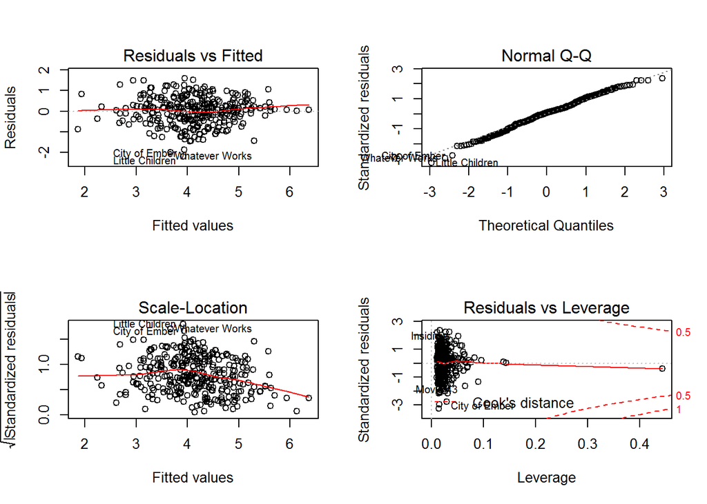

```r
par(mfrow=c(2,2))
plot(mod) #. Plot de validació.
```

```r
par(mfrow=c(1,1))
```

Ens aniria bé tenir les bandes limits als plots, per tant fem el següents gràfics:

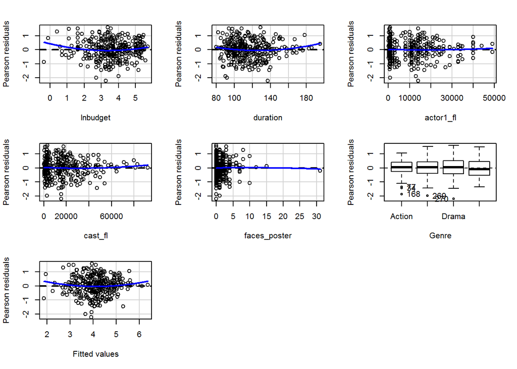

```
##              Test stat Pr(>|Test stat|)
## lnbudget        2.9889         0.003022 **
## duration        1.8046         0.072109 .
## actor1_fl       0.4328         0.665447
## cast_fl         0.9213         0.357585
## faces_poster   -0.1728         0.862958
## Genre
## Tukey test      2.0747         0.038012 *
## ---
## Signif. codes:  0 '***' 0.001 '**' 0.01 '*' 0.05 '.' 0.1 ' ' 1
```

```r
residualPlots(mod)
```

Normalment només mirem el general (fitted values), pero per validar el model es important tambe enfontar els residus entont cada una de les variables que tenim. I enlloc dun scatterplot, per a les categòriques tenim boxpllots.

són les distribucons dels residus entre les variables que hi ha dins del model.També es aconsellable fer-ho amb les variables que hem descartat per si es poden tornar a ficar.

Què es el que hem d’esperar dels residus? Que la linia blava sigui horitzontal, indicant que els residus no tenen tendència, o la mediana (al boxplot) horitzontal al voltant del 0 (distribució simèrica). El fet que totes les caixes siguin simètriques ens garanteix que la var gènere ja ens explica tot el possible.

Els dos primers plots: semplba que no és linial la liniea blava, sinó curva. Pot ser es pot justificar dient que hi ha menys punts a les parts amb menys punt i pertant s’ha d’ignorar o també que la variable té sentit que els residus siguin quadratics, etc..

Lo important es veure l’aleatoritat es fa respecte l’eix vertical (amunt i avall) i no el horitzontal (dreta i esquerra), ja que al ser un estudi observacional, pot ser no s’ha aleatoritzat el faces_poster i per tant pot haver valors atipics, lo important es que les variancies siguin iguals, que amumnt i avall la distribucio sigui totalment aleatoria. És això el que enspermet validar el model.

Igualment, el residualPlot ens torna una taula al final amb pvalors que el que fan es considerar introduir un terme quadratic en el model, o sigui considera que la relació no és lineal- si el pvalor es significatiu, per exemple per al p valor, (Ho: deixa el model lineal, H1: afageix un terme quadràtic) com és significatiu, ens està diguent que millor que afagim un terme quadràtic.

El tukey test el fa per tot. A la vista d’aquests pvalors, el que ens esta indicant es que si introduim el lnbudget al quadrat, la relació de la recaptacio y el logaritme del presupost millorará.

Normalitat:

```r
shapiro.test(resid(mod))
```

```
##
##  Shapiro-Wilk normality test
##
## data:  resid(mod)
## W = 0.99331, p-value = 0.163
```

```r
shapiro.test(rstudent(mod))
```

```
##
##  Shapiro-Wilk normality test
##
## data:  rstudent(mod)
## W = 0.99323, p-value = 0.1559
```

```r
par(mfrow=c(1,2))
qqPlot(resid(mod))
```

```
## Little Children   Whatever Works
##              270              269
```

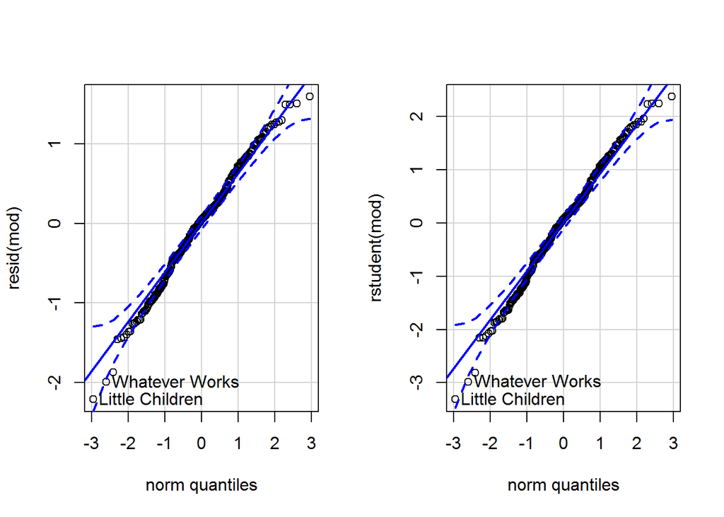

```
## Little Children   Whatever Works
##              270              269
```

```r
qqPlot(rstudent(mod))
```

```r
par(mfrow=c(1,1))
```

Amb els polots podem concloure que mes o menys es segueixla linia desitjada i el pvalor ens confirma la normalitat del model.

Plot de influencia (substitueix el de la corba de nivell, del leverage i la dist de cook):

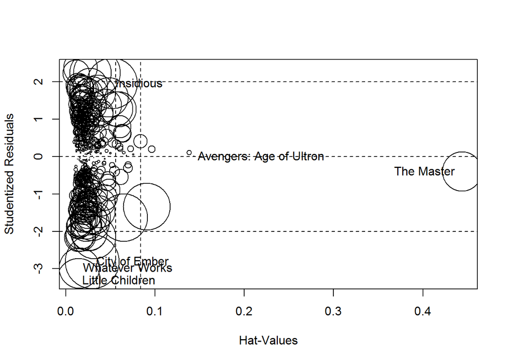

```
##                               StudRes        Hat        CookD
## Avengers: Age of Ultron   0.005091397 0.14368627 4.848456e-07
## City of Ember            -2.811180732 0.02978369 2.637372e-02
## The Master               -0.395364650 0.44378128 1.389469e-02
## Whatever Works           -2.980289798 0.01519025 1.484861e-02
## Little Children          -3.310671594 0.01441147 1.725827e-02
## Insidious                 1.960631351 0.05162203 2.303958e-02
```

```r
influencePlot(mod)
```

La dist de cook es el radi de les boles. Els leverages (hat values) son a l’eix x. Les dades mes influents son les que tenen les boles mes grans (distancia de cook = influencia real). si estan molt a la dreta es que tenen leverage gran (influencia a priori, allunyades de la recta)

Bonferroni:

```r
outlierTest(mod)
```

```
## No Studentized residuals with Bonferonni p < 0.05
## Largest |rstudent|:
##                   rstudent unadjusted p-value Bonferonni p
## Little Children  -3.310672          0.0010399      0.33483
```

Si el pvalor es major a 0.05, tot i que el pvalor sense ajust d’aques valor indiqui que es una obs extrema, significa que es un valor aleatoriament extrem i que per tant no el considerarem atipic

Bonferroni mira el pvalor davant totes les observacions i no nomes de la observació sola. Cal fer el test per als valors aripics per confirmar que ho son o no.

Efectes sobre la Y y cada una de la seva escala:

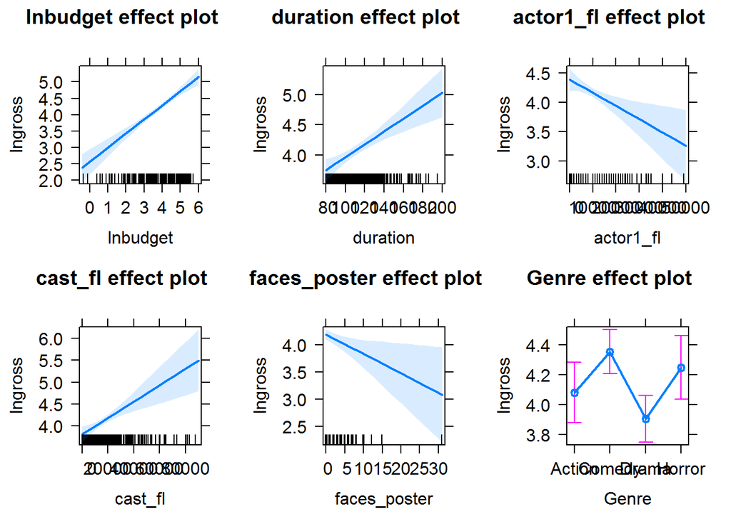

```r
plot(allEffects(mod))
```

Serveix per interpretar l’efecte, però compte que les escales poden ser diferents!

Predicció:

Pel valor esperat(confidence) i per un cas en particular(Prediction)

```r
pr<-predict(mod,newdata=data.frame(lnbudget=log(20),duration=90,year="2013-2016",director_fl=0,actor1_fl=0,actor2_fl=0,cast_fl=0,faces_poster=1,Genre="Horror"),interval="confidence")
exp(pr)
```

```
##        fit      lwr      upr
## 1 37.84457 30.45204 47.03171
```

```r
pr2<-predict(mod,newdata=data.frame(lnbudget=log(20),duration=90,year="2013-2016",director_fl=0,actor1_fl=0,actor2_fl=0,cast_fl=0,faces_poster=1,Genre="Horror"),interval="prediction")
exp(pr2)
```

```
##        fit     lwr      upr
## 1 37.84457 9.68223 147.9217
```